# Esha_exploration

## R Markdown

Uploading the data:

```r
library(tidyverse)
library(RColorBrewer)
library(paletteer)
library(janitor)
library(here)
library(skimr)
library(ggthemes)
library(naniar)
library(readr)
library(shiny)
library(shinydashboard)
```

```r
library(stringr)
library(ggplot2)
```

```r
nectar_perflower <- read_csv(here("potential_datasets", "AgriLand_Nectar_perflower.csv"))
nectar_perflower <- janitor::clean_names(nectar_perflower)
```

```r
nectar_perflower
```

```
## # A tibble: 3,303 x 19
##    species location habitat id    bagging rinsing bagging_date bagging_hour
##    <chr>   <chr>    <chr>   <chr> <chr>   <chr>   <chr>        <time>
##  1 Acer p… clifton… grassl… 2012… bag     Y       3/5/12       16:00
##  2 Acer p… clifton… grassl… 2012… bag     Y       3/5/12       16:00
##  3 Acer p… clifton… grassl… 2012… bag     Y       3/5/12       16:00
##  4 Acer p… clifton… grassl… 2012… bag     Y       3/5/12       16:00
##  5 Acer p… clifton… grassl… 2012… bag     Y       3/5/12       16:00
##  6 Acer p… clifton… grassl… 2012… bag     Y       3/5/12       16:00
##  7 Acer p… clifton… grassl… 2012… bag     Y       3/5/12       16:00
##  8 Acer p… clifton… grassl… 2012… bag     Y       3/5/12       16:00
##  9 Acer p… clifton… grassl… 2012… bag     Y       3/5/12       16:00
## 10 Acer p… clifton… grassl… 2012… bag     Y       3/5/12       16:00
## # … with 3,293 more rows, and 11 more variables: collection_date <chr>,
## #   collection_hour <time>, year <dbl>, temp <dbl>, hum <dbl>, plant_no <dbl>,
## #   flower_no <dbl>, flower_age <chr>, flower_sex <chr>,
## #   sugar_in_micrograms_flower_24h <dbl>,
## #   sugarmax_in_micrograms_flower_24h <dbl>
```

```r
nectar_perflower %>%
  separate(species,
           into = c("genus", "species")) %>%
  separate(bagging_date,
           into = c("bagging_day", "bagging_month", "bagging_year"),
           sep = "/")
```

```
## # A tibble: 3,303 x 22
##    genus species location habitat id    bagging rinsing bagging_day
##    <chr> <chr>   <chr>    <chr>   <chr> <chr>   <chr>   <chr>
##  1 Acer  pseudo… clifton… grassl… 2012… bag     Y       3
##  2 Acer  pseudo… clifton… grassl… 2012… bag     Y       3
##  3 Acer  pseudo… clifton… grassl… 2012… bag     Y       3
##  4 Acer  pseudo… clifton… grassl… 2012… bag     Y       3
##  5 Acer  pseudo… clifton… grassl… 2012… bag     Y       3
##  6 Acer  pseudo… clifton… grassl… 2012… bag     Y       3
##  7 Acer  pseudo… clifton… grassl… 2012… bag     Y       3
##  8 Acer  pseudo… clifton… grassl… 2012… bag     Y       3
##  9 Acer  pseudo… clifton… grassl… 2012… bag     Y       3
## 10 Acer  pseudo… clifton… grassl… 2012… bag     Y       3
## # … with 3,293 more rows, and 14 more variables: bagging_month <chr>,
## #   bagging_year <chr>, bagging_hour <time>, collection_date <chr>,
## #   collection_hour <time>, year <dbl>, temp <dbl>, hum <dbl>, plant_no <dbl>,
## #   flower_no <dbl>, flower_age <chr>, flower_sex <chr>,
## #   sugar_in_micrograms_flower_24h <dbl>,
## #   sugarmax_in_micrograms_flower_24h <dbl>
```

## Analyses: which habitats have the least and most amount of nectar per flower? How has this changed over the years?

### Exploration of the data:

Habitats with the most nectar (using sugar_in_micrograms_flower_24h):

```r
nectar_perflower %>%
  group_by(habitat) %>%
  filter(sugar_in_micrograms_flower_24h != "NA") %>%
  summarize(mean_nectar = mean(sugar_in_micrograms_flower_24h)) %>%
  arrange(desc(mean_nectar))
```

```
## # A tibble: 31 x 2
##    habitat                  mean_nectar
##    <chr>                          <dbl>
##  1 pond                           3949.
##  2 managed grassland-garden       1424.
##  3 heathland-mooseland            1410.
##  4 street                          953.
##  5 hedgerow                        744.
##  6 woodland-carpark                605.
##  7 pot                             563.
##  8 wetland                         462.
##  9 cultivated farmland             437.
## 10 woodland                        424.
## # … with 21 more rows
```

Looks like the pond environment has the biggest average of nectar collected per flower.

Habitats with the least nectar:

```r
nectar_perflower %>%
  group_by(habitat) %>%
  filter(sugar_in_micrograms_flower_24h != "NA") %>%
  summarize(mean_nectar = mean(sugar_in_micrograms_flower_24h)) %>%
  arrange(mean_nectar)
```

```
## # A tibble: 31 x 2
##    habitat                 mean_nectar
##    <chr>                         <dbl>
##  1 bog                           0
##  2 rock                          0
##  3 hedgerow-woodland             0.307
##  4 coastland-grassland           1.41
##  5 grassland-hedgerow           13.6
##  6 grassland-carpark            18.7
##  7 grassland-coastland          28.7
##  8 allotments                   44.7
##  9 heathland                    58.9
## 10 woodland-nature reserve      59.9
## # … with 21 more rows
```

That’s weird that the bog and rock have a mean nectar value of 0.0. Let’s take a closer look at them:

```r
nectar_perflower %>%
  filter(habitat == "bog" | habitat == "rock")
```

```
## # A tibble: 17 x 19
##    species location habitat id    bagging rinsing bagging_date bagging_hour
##    <chr>   <chr>    <chr>   <chr> <chr>   <chr>   <chr>        <time>
##  1 Helian… downs    rock    2011… bag     Y       20/09/2011   15:00
##  2 Helian… downs    rock    2011… bag     Y       20/09/2011   15:00
##  3 Helian… downs    rock    2011… bag     Y       20/09/2011   15:00
##  4 Helian… downs    rock    2011… bag     Y       20/09/2011   15:00
##  5 Helian… downs    rock    2011… bag     Y       20/09/2011   15:00
##  6 Helian… downs    rock    2011… bag     Y       20/09/2011   15:00
##  7 Helian… downs    rock    2011… bag     Y       20/09/2011   15:00
##  8 Narthe… cleddon… bog     2012… bag     Y       29/08/2012   12:00
##  9 Narthe… cleddon… bog     2012… bag     Y       29/08/2012   12:00
## 10 Narthe… cleddon… bog     2012… bag     Y       29/08/2012   12:00
## 11 Narthe… cleddon… bog     2012… bag     Y       29/08/2012   12:00
## 12 Narthe… cleddon… bog     2012… bag     Y       29/08/2012   12:00
## 13 Narthe… cleddon… bog     2012… bag     Y       29/08/2012   12:00
## 14 Narthe… cleddon… bog     2012… bag     Y       29/08/2012   12:00
## 15 Narthe… cleddon… bog     2012… bag     Y       29/08/2012   12:00
## 16 Narthe… cleddon… bog     2012… bag     Y       29/08/2012   12:00
## 17 Narthe… cleddon… bog     2012… bag     Y       29/08/2012   12:00
## # … with 11 more variables: collection_date <chr>, collection_hour <time>,
## #   year <dbl>, temp <dbl>, hum <dbl>, plant_no <dbl>, flower_no <dbl>,
## #   flower_age <chr>, flower_sex <chr>, sugar_in_micrograms_flower_24h <dbl>,
## #   sugarmax_in_micrograms_flower_24h <dbl>
```

This chart indicates to us that the average amount of nectar collected for the bog and habitat environments is actually zero. Interesting. Though it makes sense logically that the researchers didn’t collect any nectar from the “rock” habitat, I’m curious as to how or why they weren’t able to find any in a bog (aka a wetland!) since bogs actually are home to a variety of flowers.

Plotting the habitats with the most nectar (I plotted this to accompany the chart I just made, since a visual will be better for people to look at in a powerpoint presentation):

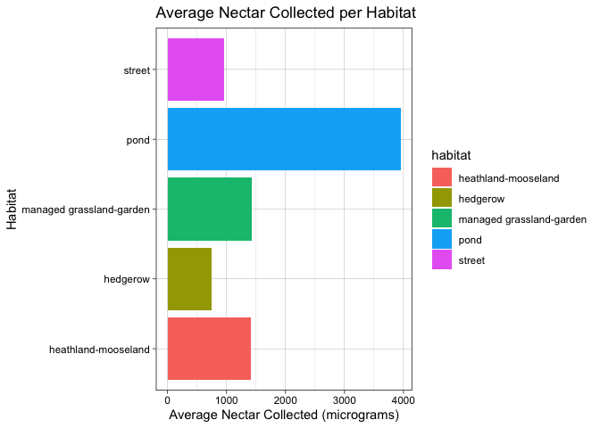

```r
nectar_perflower %>%
  group_by(habitat) %>%
  filter(sugar_in_micrograms_flower_24h != "NA") %>%
  summarize(mean_nectar = mean(sugar_in_micrograms_flower_24h)) %>%
  arrange(desc(mean_nectar)) %>%
  top_n(5) %>%
  ggplot(aes(x = habitat, y = mean_nectar, fill = habitat)) +
  geom_col() +
  labs(title = "Average Nectar Collected per Habitat", x = "Habitat", y = "Average Nectar Collected (micrograms)") +
  coord_flip() +
  theme_linedraw()
```

Habitats with the most nectar (using sugarmax_in_micrograms_flower_24h instead to see if there are significant differences):

```r
nectar_perflower %>%
  group_by(habitat) %>%
  filter(sugarmax_in_micrograms_flower_24h != "NA") %>%
  summarize(mean_nectar_from_max = mean(sugarmax_in_micrograms_flower_24h)) %>%
  arrange(desc(mean_nectar_from_max))
```

```
## # A tibble: 31 x 2
##    habitat                  mean_nectar_from_max
##    <chr>                                   <dbl>
##  1 pond                                    3949.
##  2 managed grassland-garden                1424.
##  3 heathland-mooseland                     1410.
##  4 street                                   962.
##  5 hedgerow                                 752.
##  6 woodland-carpark                         629.
##  7 pot                                      564.
##  8 wetland                                  464.
##  9 cultivated farmland                      437.
## 10 woodland                                 426.
## # … with 21 more rows
```

Looks like we get the same results as we got when we analyzed the sugar_in_micrograms_flower_24h. I wonder now what the difference between the “sugarmax_in_micrograms_flower_24h” variable and the sugar_in_micrograms_flower_24h is. Why were these variables made seperate if they show the same results?

```r
nectar_perflower %>%
  group_by(habitat) %>%
  filter(sugarmax_in_micrograms_flower_24h != "NA") %>%
  summarize(mean_nectar_from_max = mean(sugarmax_in_micrograms_flower_24h)) %>%
  arrange(mean_nectar_from_max)
```

```
## # A tibble: 31 x 2
##    habitat                 mean_nectar_from_max
##    <chr>                                  <dbl>
##  1 bog                                    0
##  2 rock                                   0
##  3 hedgerow-woodland                      0.750
##  4 coastland-grassland                    4.68
##  5 grassland-carpark                     22.9
##  6 grassland-coastland                   31.3
##  7 grassland-hedgerow                    45.2
##  8 allotments                            50.0
##  9 woodland-nature reserve               65.4
## 10 grassland-wetland                     80.8
## # … with 21 more rows
```

Plotting the habitats with the most nectar (using sugarmax instead):

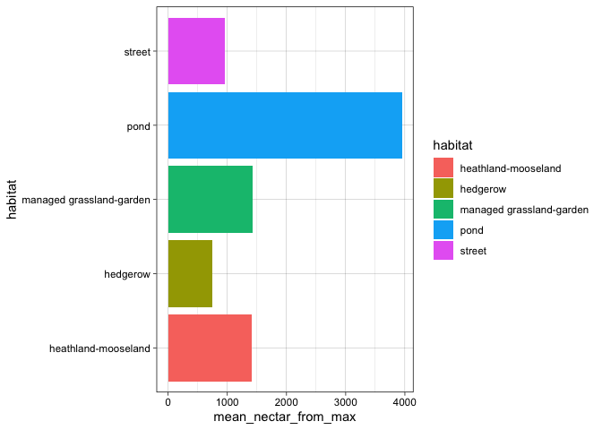

```r
nectar_perflower %>%
  group_by(habitat) %>%
  filter(sugarmax_in_micrograms_flower_24h != "NA") %>%
  summarize(mean_nectar_from_max = mean(sugarmax_in_micrograms_flower_24h)) %>%
  arrange(desc(mean_nectar_from_max)) %>%
  top_n(5) %>%
  ggplot(aes(x = habitat, y = mean_nectar_from_max, fill = habitat)) +
  geom_col() +
  coord_flip() +
  theme_linedraw()
```

I made this plot to try and see if we could represent how the average nectar collected changed over 2011-2012 (the years that the study was conducted):

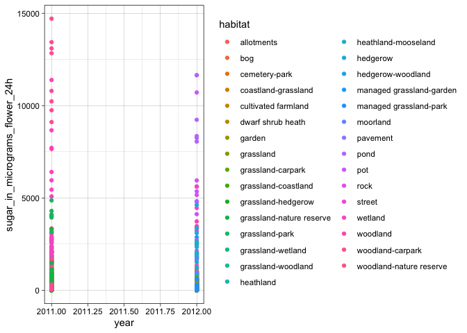

```r
nectar_perflower %>%
  group_by(habitat, year) %>%
  filter(sugarmax_in_micrograms_flower_24h != "NA") %>%
  ggplot(aes(x = year, y = sugar_in_micrograms_flower_24h, color = habitat)) +
  geom_point() +
  theme_linedraw()
```

This is clearly not the best way to show how the mean nectar collected changes over time. Let’s try a different kind of plot:

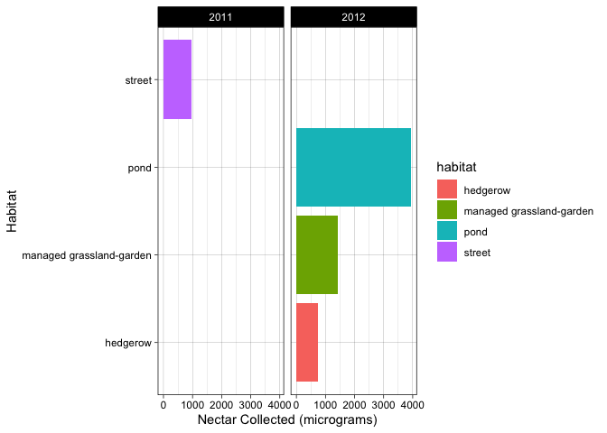

```r
nectar_perflower %>%
  group_by(habitat, year) %>%
  filter(sugar_in_micrograms_flower_24h != "NA") %>%
  filter(habitat == "street" | habitat == "pond" | habitat == "managed grassland-garden" | habitat == "hedgerow" | habitat == "healthland-mooseland") %>%
  summarize(mean_nectar = mean(sugar_in_micrograms_flower_24h)) %>%
  ggplot(aes(x = habitat, y = mean_nectar, fill = habitat)) +
  geom_col() +
  coord_flip() +
  facet_wrap(~year) +  labs(x = "Habitat", y = "Nectar Collected (micrograms)") +
  theme_linedraw()
```

This is a very problematic aspect of this data. Unfortunately, it looks as if the researchers didn’t stay consistent and revisit some of the habitats they visited in 2011/didn’t visit some of the places they went to in 2012 back in 2011.

I performed the following analyses to figure out if there are any habitats which the scientists collected nectar from in 2011 and 2012:

```r
nectar_perflower %>%
  group_by(habitat) %>%
  filter(sugar_in_micrograms_flower_24h != "NA") %>%
  filter(year == "2011")
```

```
## # A tibble: 1,759 x 19
## # Groups:   habitat [10]
##    species location habitat id    bagging rinsing bagging_date bagging_hour
##    <chr>   <chr>    <chr>   <chr> <chr>   <chr>   <chr>        <time>
##  1 Achill… brandon… grassl… 2011… bag     Y       27/07/2011   11:30
##  2 Achill… brandon… grassl… 2011… bag     Y       27/07/2011   11:30
##  3 Achill… brandon… grassl… 2011… bag     Y       27/07/2011   11:30
##  4 Achill… brandon… grassl… 2011… bag     Y       27/07/2011   11:30
##  5 Achill… brandon… grassl… 2011… bag     Y       27/07/2011   11:30
##  6 Achill… brandon… grassl… 2011… bag     Y       27/07/2011   11:30
##  7 Achill… brandon… grassl… 2011… bag     Y       27/07/2011   11:30
##  8 Achill… brandon… grassl… 2011… bag     Y       27/07/2011   11:30
##  9 Achill… brandon… grassl… 2011… bag     Y       27/07/2011   11:30
## 10 Achill… brandon… grassl… 2011… bag     Y       27/07/2011   11:30
## # … with 1,749 more rows, and 11 more variables: collection_date <chr>,
## #   collection_hour <time>, year <dbl>, temp <dbl>, hum <dbl>, plant_no <dbl>,
## #   flower_no <dbl>, flower_age <chr>, flower_sex <chr>,
## #   sugar_in_micrograms_flower_24h <dbl>,
## #   sugarmax_in_micrograms_flower_24h <dbl>
```

```r
nectar_perflower %>%
  group_by(habitat) %>%
  filter(sugar_in_micrograms_flower_24h != "NA") %>%
  filter(year == "2012")
```

```
## # A tibble: 1,469 x 19
## # Groups:   habitat [23]
##    species location habitat id    bagging rinsing bagging_date bagging_hour
##    <chr>   <chr>    <chr>   <chr> <chr>   <chr>   <chr>        <time>
##  1 Acer p… clifton… grassl… 2012… bag     Y       3/5/12       16:00
##  2 Acer p… clifton… grassl… 2012… bag     Y       3/5/12       16:00
##  3 Acer p… clifton… grassl… 2012… bag     Y       3/5/12       16:00
##  4 Acer p… clifton… grassl… 2012… bag     Y       3/5/12       16:00
##  5 Acer p… clifton… grassl… 2012… bag     Y       3/5/12       16:00
##  6 Acer p… clifton… grassl… 2012… bag     Y       3/5/12       16:00
##  7 Acer p… clifton… grassl… 2012… bag     Y       3/5/12       16:00
##  8 Acer p… clifton… grassl… 2012… bag     Y       3/5/12       16:00
##  9 Acer p… river f… wetland 2012… bag     N       15/04/2012   16:00
## 10 Acer p… river f… wetland 2012… bag     N       15/04/2012   16:00
## # … with 1,459 more rows, and 11 more variables: collection_date <chr>,
## #   collection_hour <time>, year <dbl>, temp <dbl>, hum <dbl>, plant_no <dbl>,
## #   flower_no <dbl>, flower_age <chr>, flower_sex <chr>,
## #   sugar_in_micrograms_flower_24h <dbl>,
## #   sugarmax_in_micrograms_flower_24h <dbl>
```

I’m making this graph to compare how the average nectar collected changed over 2011-2012:

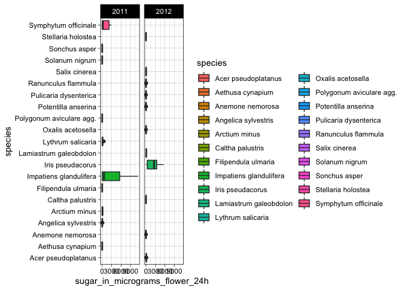

```r
wetland_by_species <- nectar_perflower %>%
  filter(habitat == "wetland") %>%
  filter(sugar_in_micrograms_flower_24h != "NA") %>%
  ggplot(aes(x = species, y = sugar_in_micrograms_flower_24h, fill = species), legend = "NULL") +
  geom_boxplot() +
  coord_flip() +
  facet_wrap(~year) +
  theme_linedraw()

wetland_by_species
```

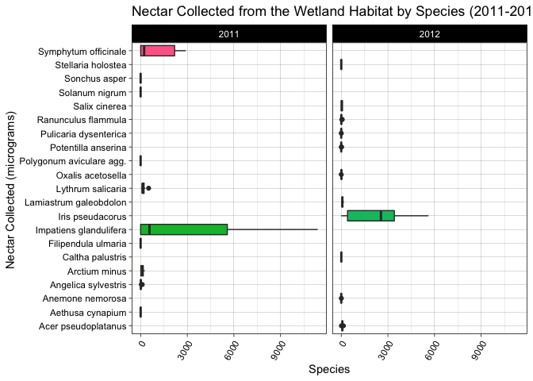

```r
wetland_by_species+theme_linedraw()+
  theme(legend.position = "none",
        axis.text.x = element_text(angle = 60, hjust=1))+
  labs(title = "Nectar Collected from the Wetland Habitat by Species (2011-2012)",
       x = "Nectar Collected (micrograms) ",
       y= "Species")
```

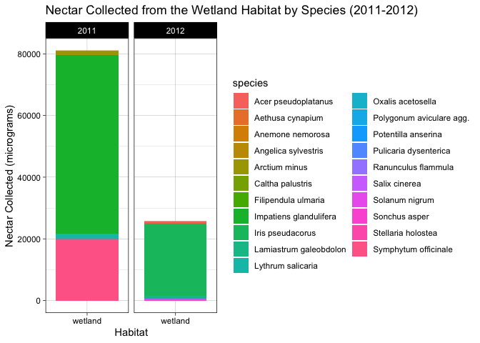

```r
nectar_perflower %>%
  filter(habitat == "wetland") %>%
  filter(sugar_in_micrograms_flower_24h != "NA") %>%
  ggplot(aes(x = habitat, y = sugar_in_micrograms_flower_24h, fill = species)) +
  geom_col() +
  facet_wrap(~year) +
  theme_linedraw() +
  labs(title = "Nectar Collected from the Wetland Habitat by Species (2011-2012)",
       x = "Habitat",
       y = "Nectar Collected (micrograms)")
```

This graph gives us a better idea of how much the nectar that we collected changed over the years.

### App for Data Organization

I made this app to actually help the researchers keep track of their data and for anyone like us to wants to analyze it. The app displays the amount of nectar collected per species in each habitat, and it allows you to select which habitat and year to focus on. This way, the researchers can keep track of where they are missing data (in other words, they can keep track of which years they neglected to visit certain habitats) and allows people analyzing the data to not jumpt to any incorrect conclusions (for example, it would be incorrect to assume that the average mean nectar collected from a certain habitat increased from 2011-2012 when the researchers didn’t actually collect any data in 2011 for that habitat).

Side note: the final, working version of my app is labeled as “esha’s_app_final”. Please do not look at the one labeled “esha’s_app”, that was a version that is broken.

Here’s the app:

```r
ui <- dashboardPage(skin = "black",
                    dashboardHeader(title = "Change in Nectar Quantities Collected in the UK (2011-2012)",
                                    titleWidth = 600),
                    dashboardSidebar(disable = T),
                    dashboardBody(
                      fluidRow(
                        box(title = "Plot Options", width = 3,
                            selectInput("x", "Select a Habitat:", choices = c("allotments", "bog", "cemetery-park", "coastland-grassland", "cultivated farmland", "dwarf shrub heath", "garden", "grassland", "grassland-carpark", "grassland-coastland", "grassland-coastland", "grassland-hedgerow", "grassland-nature reserve", "grassland-park", "grassland-wetland", "grassland-woodland", "heathland", "heathland-mooseland", "hedgerow", "hedgerow-woodland", "managed grassland-park", "moorland", "pavement", "pond", "pot", "rock", "street", "wetland", "woodland", "woodland-carpark", "woodland-nature reserve"),
                                        selected = "wetland"),
                            selectInput("y", "Select a Year:", choices = c("2011", "2012"),
                                        selected = "2011"),
                            sliderInput("pointsize", "Select the Point Size", min = 1, max = 5, value = 2, step = 0.5),
                            hr(),
                            helpText("Reference: Baude M, Kunin W, Boatman N, Davies N, Gillespie M, Morton D, Smart S, Memmott J.
               Historical nectar assessment reveals the fall and rise of floral resources in Britain. 2016.")
                        ), # close the first box
                        box(title = "Nectar Collection by Habitat", width = 6,
                            plotOutput("plot", width = "600px", height = "500px")
                        ) # close the second box
                      ) # close the row
                    ) # close the dashboard body
) # close the ui

server <- function(input, output, session) {

  output$plot <- renderPlot({
    nectar_perflower %>%
      filter(habitat==input$x & year ==input$y) %>%
      ggplot(aes_string(x = "species", y = "sugar_in_micrograms_flower_24h", fill = "species")) +
      geom_point(size=input$pointsize, alpha=0.8) +
      geom_col()+
      theme(axis.text.x = element_text(angle = 60, hjust = 1)) +
      labs(y = "Nectar Collected (micrograms)",
           x = "Species")
  })

  # stop the app when we close it
  session$onSessionEnded(stopApp)
}

shinyApp(ui, server)
```

Shiny applications not supported in static R Markdown documents